# **The accelerated R Course:** Practical 1 *Introduction to R*

Chris Clements

# 1 This weeks pre-session reading

**Time - 20 minutes**

## 1.1 Welcome…

This is the style of the worksheets that will form the backbone of this course. This will allow people to work through the code at their own pace (whilst getting help in class from us), and also work in their own time as you continue to learn bioinformatics skills.

## 1.2 …to R

Now to start the course proper - the first thing to do is to install R and R studio. R is the statistical software that all the analyses are carried out in (and the coding language you are learning). R studio is a nice shiny user interface which adds loads of additional functunality to R and makes it easy and simple to do a lot of advanced computing. You need both.

## 1.3 ILOs

Each week we will cover a range of different topics. The workbook will briefly recap what we did the previous week, and what the Intended Learning Outcomes (ILOs) for the coming week are. So, this week our ILOs are:

- Learn how to install R and R studio and navigate around inside these programs
- Learn some best-practice rules for coding
- Learn how to carry out basic calculations in R
- Learn about different data types in R and how it stores these data
- Briefly discuss functions and why the are so useful

## 1.4 Setting up R

### 1.4.1 Installing R

To install R (if it isnt already installed on the machine you are working with) go to [here](https://cran.r-project.org/mirrors.html). Then select the nearers CRAN mirror (scroll down to find “UK” and selet the Bristol server). Then select your opperating system.

#### 1.4.1.1 On Mac OS X

Select the latest release (top of the list) or the one most appropriate for your Mac OS X version, and download the .pkg. Open this and follow the instructions.

#### 1.4.1.2 On Windows

Click on “base”, then click on the top link (e.g. *Download R 3.6.3 for Windows (83 megabytes, 32/64 bit)* ) and then open that and follow the instructions.

### 1.4.2 Installing RStudio

To install RStudio, go to the link [here](https://www.rstudio.com/). Go to Products -> Open Source -> Rstudio. Select RStudio Desktop, and then select the Open Source Edition download link. On the next page select the “Free” option and download. The select the version you want to download (depending on your operating system). Click to download it, and then open the file and follow the instructions.

### 1.4.3 Language

Before we go any further, its really important to make sure you have your keyboards set to english (US or UK). R is logical, but not smart - we need to be able to input the correct characters - e.g. ` vs ’ - or our code won’t work. It may be easier for you to get a UK keyboard to plug into your laptop if you are struggling.

## 1.5 RStudio - an introduction

Now you have r and RStudio installed, lets open RStudio and get started.

### 1.5.1 Navigating in RStudio

When you first open RStudio you will be greeted by the following:

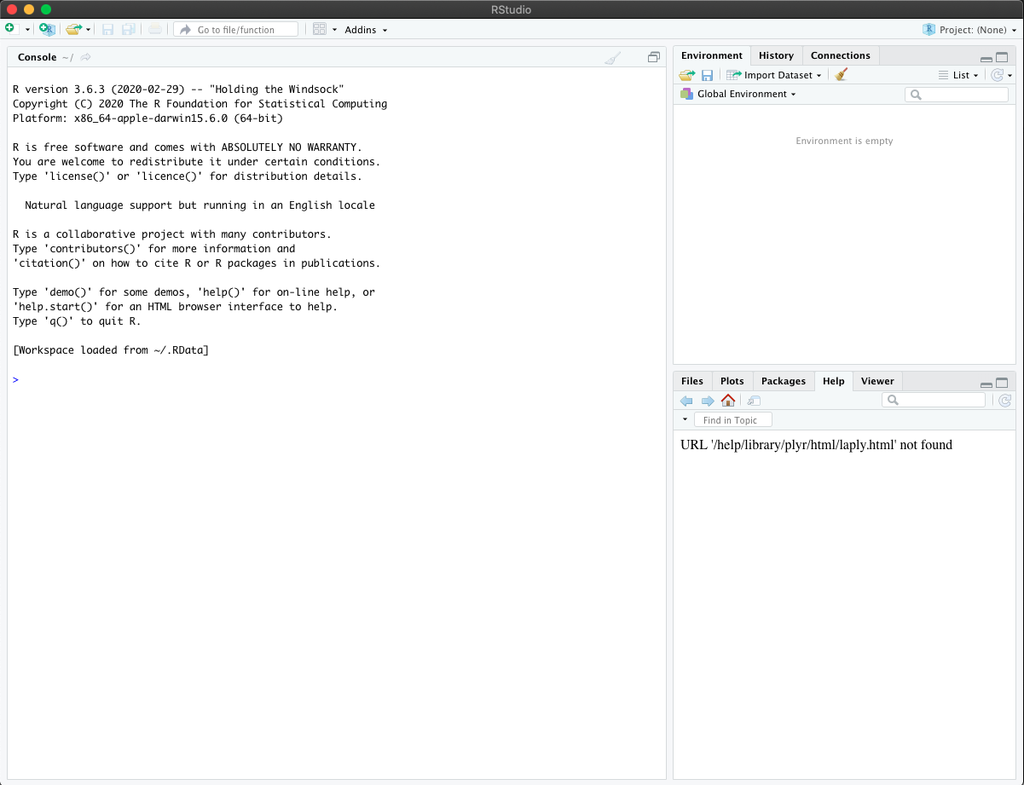

This is the environment you’ll be working in from now on, and we will briefly introduce what the various parts of this screen mean, but the easiest way to get to know them is to learn as you work.

First off, this is called the Console:

[figure not shown]

The console is basically the calculator of R. When you run code it will appear in the console so you can see what you have run so far. You can also enter code directly into the console.

This is the “global environment”:

[figure not shown]

It shows all the objects, data, functions etc which have been loaded into R. Its empty at the moment (because we haven’t done anything) but will fill up quickly once we get going.

This bottom right box can display a lot of different things - graphics you have made (under “Plots”), any external data files you have loaded in (under “Files”), what packages you currently have loaded and what other packages are available on your computer (under “Packages” - you can see the naming theme here….), and help under the “Help” tab. The “Help” tab will become very important later on.

[figure not shown]

# 2 Coding in R

**Time - 10 minutes**

## 2.1 Coding in the console

We talked briefly about the console - this is where the code oyu have execited is displayed. You can work directly in the console, for example click in console and you should see a flashing cursor - try typing:

```
1+1
```

and hitting “return” or “enter” on your keyboard. This executes the line of code you have typed into the console.

you should see the following:

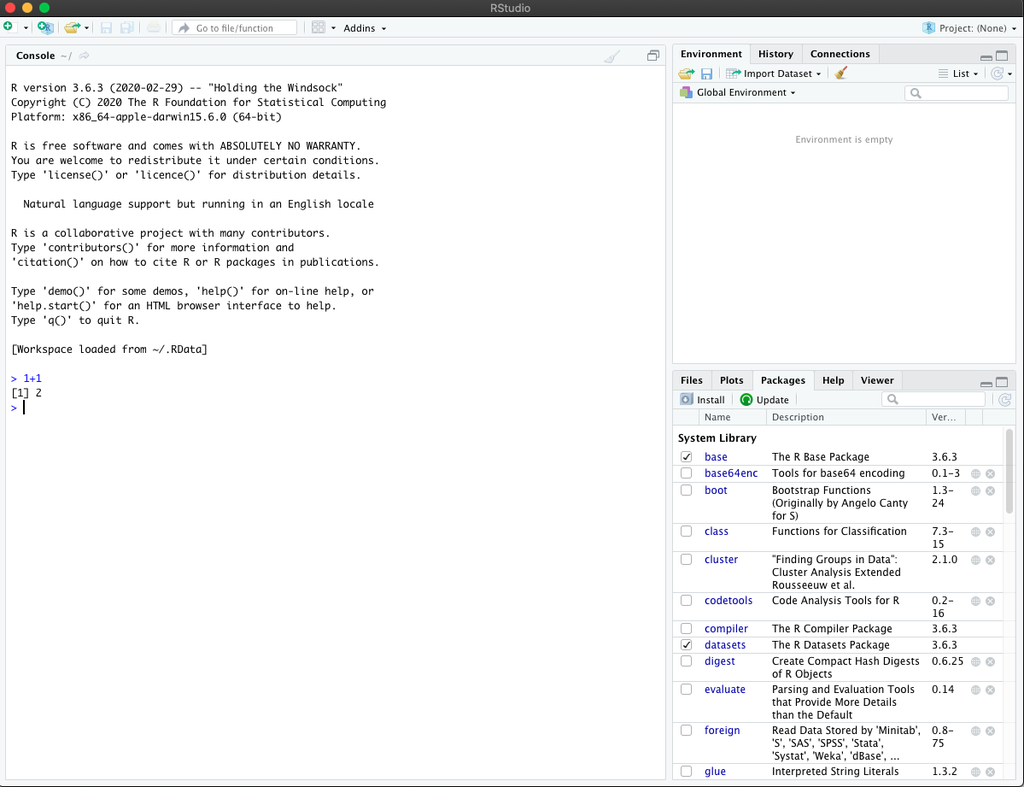

Which shows you that when you add 1 and 1 together you get 2. Shocking!

You can see that the blue text is what you have executed:

1+1

and the black text is the solution to the code:

```
[1] 2
```

The `[1]` lets us know that this value is the 1st value in a sequence (in this case there is only 1 value in the sequence, but you can have more).

Fantastic! You can code in R!

As we said, here we are doing the calculations and executing the code in the **console**. There are some advantages to this:

- it’s very quick
- … actually that’s about the only advantage

Coding directly into the console is great for carrying out some quick calculations, or trying a bit of code, but your code isn’t saved anywhere. You can see code which has been recently run (click in the console and try pressing the up arrow key), but this won’t be saved if you close RStudio. This is fine when the code is very simple (like 1+1) but is impractical as soon as the code becomes complex. There is, however, another option:

## 2.2 Writing a script

A “script” is a text document which stores code. It means you can run that code again very easily (you dont have to re-type it every time to use it) and you can share it easily with other people (remember the ethos of open-source science). You can also make detailed notes on what your code does so you will remember when you come back to it in 6 months time.

To start a script go to:

[figure not shown]

You will see that RStudio has changed now - the console, global environment, and files/plots/packages/help sections are all still there, and now so is a new section, named **“Untitled1”**.

[figure not shown]

This is your script, you can type in it, and then save that code and come back to it later. Lets try our 1+1 again that we did earlier - type this into your black script:

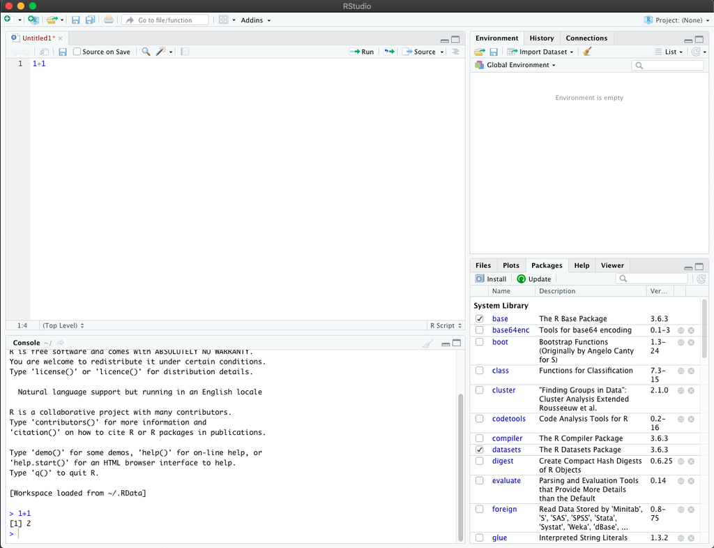

If you press “return” or “enter” now you will see that this code isnt executed - you just start a new line. This is because the script doesn’t act like the console - to execute a line of code in a script you need to put your cursor on that line, and then press `"command" + "return"` if you are on a Mac, or `"ctrl" + "r"` if you are in Windows. If you want to select multiple lines of code to run then you can do this by highlighting the code you want to run and then running that with the above command. You can also run part of a line (e.g. by just selecting the part of the code you want to run. Try running the code you just wrote in your script. You should see:

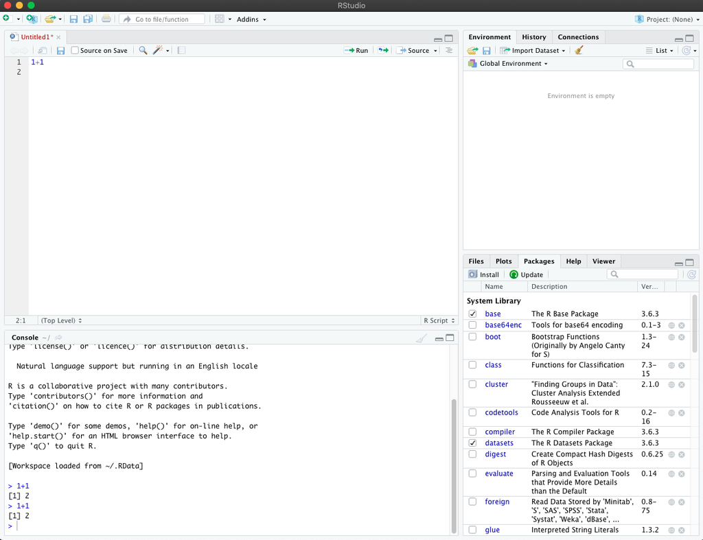

The code you wrote (`1+1`) has now been executed in the console and you can see that you have done the calculation again giving you the answer `2`.

Working in a script has many advantages over working in the console:

- you can save your code
- you can try multiple different ways of doing something and just keep the code that works
- if your code doesn’t work you can go back and change it without having to rewrite the whole thing
- you can write really complex code
- you can **ANNOTATE** your code (see below)
- your code will be reproducible (remember *OPEN SCIENCE*!)
- people can help you if you get stuck

These are the basics of R - you have a console, and a script, and you write code in the script and when you execute it it runs in the console and gives you an answer. Of course it gets more complicated as you write more compelex scripts, but using RStudio in this way is the premise for all your future work.

# 3 Annotating your code

**Time - 5 minutes**

I am going to quickly segway to a really important point which we need to talk about now, and that is annotating your code. “annotating” just means making notes on what your code does when you write it. This is incredibly important - you will forget almost instantly what your code does and when you come to look at it in a few weeks, or months, or years, if you haven’t annotated it you will forget what it’s doing and therefore won’t know if its working properly. You can annotate your code really easily in R using the “#” symbol. Anything written on the line following a “#” is not run by R this means you can keep really detailed notes on what your code does and you should do this AS YOU WRITE YOUR CODE!

For example:

```
##add 1 and 1 together:
1+1
```

Helpfully R ignores any spaces - blank lines:

```r
##add 1 and 1 together:
1+1

##subtract 2 from 20:
20 - 2
```

which means we can nicely space out or code to make it easier to read. We can also make use of the fact that R allows code to be indented:

```r
##add 1 and 1 together:
1+1

  ##subtract 2 from 20:
  20 - 2
```

Which is really useful when we start to look at code nested within code later on. You can indent your code using the Tab key, or Code -> Reindent Lines from the drop down menu (also see shortcuts in the menu, which will be different for Windows and Mac). RStudio also helps with this as it will automatically indent some sections of code and color them to try and make your code as clear and readable (for humans) as possible.

We expect your code to be annotated throughout this course. You can use the annotated code we provide to give you an idea of how detailed the notes should be. (**Hint - the annotations should be detailed enough for someone else to understand what is going on, but not so detailed your R script is like a book**)

*Task*

Annotate your new R script and save it into a folder for this Bioinformatics course - try to keep on top of your organisation from the start as you will be generating quite a lot of scripts and reading to do (consider splitting up the r scripts by workshop or whatever works best for your personally).

# 4 Basic coding in R

**Time - 20 minutes**

### 4.0.1 Basic calculations

We have already briefly looked at what we can do with R by trying out the `1+1` code in the console and in our script. This is effectively using R as a very over powered calculator:

```r
1+1
```

```
## [1] 2
```

| Basic maths | Code | Example |
| --- | --- | --- |
| Add | `+` | `1+1` |
| Subtract | `-` | `2-4` |
| Divide | `/` | `12/3` |
| Multiply | `*` | `2*4` |
| Power | `^` | `3^2` |
| Parentheses | `()` | `3*(1+2)` |

The above are the building blocks of the code you will be writing and allow you to do intermediatly complex tasks:

```r
(-6 + (6^2 -4 * 1 * 5)^(1/2)) / (2 * 1)
```

```
## [1] -1
```

R uses the standard mathmatical order of operations/precendence (if you need a refresher have a look [here](https://en.wikipedia.org/wiki/Order_of_operations)):

1. Exponents
2. Multiplication and Division
3. Addition and Subtraction

You need to bear this in mind when you are carrying out calculations!

## 4.1 `Inf` & `NaN`

Some calculations will produce non-trivial answers, and we need to very quickly discuss how R deals with these. The first is what happens when you divide 1 by 0:

```r
1/0
```

```
## [1] Inf
```

```r
-1/0
```

```
## [1] -Inf
```

Rather than casuing an error, this returns the `Inf` value - R understands that the answer to this is infinite and will allow you to continue with your calculations (most of the time).

The second problematic value R can return is `NaN` - which is generated for example when:

```r
##divide 0 by 0
0/0
```

```
## [1] NaN
```

Because mathmatically 0/0 is not defined, R returns a value of `NaN` - “Not A Number”.

Most commonly you will see `Inf` or `NaN` when there is an error somewhere in your code, so if these ever arise (and they will!) you will need to check whether (1) there is an error in the code, or whether you were expecting them, (2) whether their presence is an issue for the forward calculations.

## 4.2 NA

There is one other common value you will see when using R, and this is NA. NA stands for “Not Available” and indicates missing values in data. NAs are usally ignore by R (or can be removed). We will discuss them more below and in future workbooks.

## 4.3 Assigning values to objects

Obviously, using R as we discussed above is very limiting in terms of the calculations you can achieve. Key to unleashing us from the shackles of having to write everything out in long hand is dealing with **Objects** in R. This works in the same way as your calculator’s memory - but we can name and store huge numbers of objects to allow us to carry out complex calculations.

Creating objects in R is very simple, we use the *assignment operator* `<-`. Conveniently RStudio has a shortcut to insert the assignment operator - pres *Alt + -* on Windows or *option + -* on Mac OS.

```r
##assign values to objects a and d
a <- 1
d <- 10
```

Once we have defined objects we can see their values by typing their name in the R console and running it or running the same from your script:

```r
##assign values to object a
a <- 1
a
```

```
## [1] 1
```

The assignment opperator allows us to save values as objects, either as above by simply defining outright what the value of `a` is or by making an object the product of some piece of code:

```r
##define h
h <- (-6 + (6^2 -4 * 1 * 5) ^ (1 / 2)) / (2 * 1)
```

Once we have defined objects we can then use these in calculations, and save these as new objects:

```r
##define d
d <- 10

##define h
h <- (-6 + (6^2 -4 * 1 * 5)^(1/2)) / (2 * 1)

##K is h divided by d
k <- h/d
k
```

```
## [1] -0.1
```

**Warning - R will overwrite (without warning you first) an object if you assign another object the same name**:

```r
##define k
k <- 5/4

##define k again
k <- 20

##look at the value of k
k
```

```
## [1] 20
```

When we have defined these objects they are saved into R’s memory. R has different memory allocations - called Environments - which is a complex topic we will touch on later in course. At the moment all you need to know there are various environments in which R can store your variables. Doing what we have done and defining them in the console above has saved these objects into the **Global Environment**. Try running the folling code in your R console:

```r
##define l
l <- 5
```

Now look at your global environment panel in the top right of RStudio. You should see that you have a new object under “Values” called `l` with a value of `5`. These objects in the global environment are globally accessible to code you write that has that object in it. E.g.

```r
##calculate p
p <- l * 3
```

**Insight** - as we will see later some environments are specific to certain functions, and are created and removed in the background as code is run. Objects in these environments appear and and removed from R’s memory after the code is run whilst objects in the global environment are present until R is closed, or the memory wiped.

## 4.4 Style guide and naming conventions

Its worth spending a little time talking about how we name objects and files in R and indeed how we should approach this more generally. Hadley Wickham (the creator of RStudio) has a good guide to this ([here](http://adv-r.had.co.nz/Style.html)). Here are the most important points for you at this stage, but read up on the rest of the advice in your own time:

1. File names should be meaningful
   - When you save your R code don’t save it as `'version 1.R'`
   - Better: `"Covid-19 modelling.R"*`
2. Object names should be lowercase, short, and meaningul.
   - e.g. `day_one`
3. Avoid using names already defined in R as functions and variables
   - We haven’t introduced you to functions yet (see below) but as you use R you will become aware that some names are already pre-defined in R as doing specific things
   - e.g. Don’t do `c <- 10` (again see below for what `c()` does!)
4. Put spaces between all infix operators and arguments (`=`,`+`,`-`,`<-`, etc)
   - e.g. `1 + 2` and not `1+2`
   - **Except** when using `:` : `1:10`
5. Don’t put spaces when using parentheses
   - i.e. `(a + b + b)` not `( a + b + c )`

# 5 Basic data structures in R

## 5.1 Vectors

So far we have considered single numeric values saved as named objects. This is the simplest form of data in R. As you probably know, vectors are 1-dimensional objects which contain data. We have considered a vector with one value in it, but R can deal with vectors containing multiple numeric values (e.g. `2, 4, 6, 15`) or multiple character values (`"a", "z", "p"` - see below), but **cannot** include both numbers and characters. When we say **cannot** we dont mean this isn’t possible - you can *input* both numeric and character strings into a vector, but R will assume that the numeric values are to be treated as literal values - i.e. only as they are seen, and not as a number which is divisible etc. This is why the 2 below has quotation marks around it (see Character vectors for more details).

```r
##a vector containing character values
##for an explanation of c(...) see below!
c("a", 2)
```

```
## [1] "a" "2"
```

### 5.1.1 Numeric vectors

We have seen we can define a vector of length 1 using the code `b <- 2`, but to define longer vectors we need to us a function called “`c`”. We havent covered functions yet (see below) but functions are just short hand ways of doing a task. In this case, the function “`c`” allows you to combine multiple values into a vector as follows:

```r
##create a numeric vector
a <- c(1, 5, 4, 2)

##look at the vector
a
```

```
## [1] 1 5 4 2
```

You can see we use `,` to seperate the values going into a vector, be those numeric or character values.

You can retrieve the sole property of a vector (its length) using another function, called `length()`:

```r
##the length of the vector of numbers
length(a)
```

```
## [1] 4
```

`c()` can also be used to combine multiple vectors together into larger vectors:

```r
##make a vector a
a <- c(1, 5, 4, 2)

##make a vector g
g <- c(10, 2.1, 3)

##combine a and g into a new vector
c(a , g)
```

```
## [1]  1.0  5.0  4.0  2.0 10.0  2.1  3.0
```

which you can see has added vector `g` to the back of vector `a`. You can also specify vectors within other vectors:

```r
##make a vector a
a <- c(1, 5, 4, 2)

##make a new vector g which includes a
g <- c(10, 2.1, a, 3)

##look at g
g
```

```
## [1] 10.0  2.1  1.0  5.0  4.0  2.0  3.0
```

Which you can see has added the vector `a` between the values 2.1 and 3 and created a new vector `g`.

Vectors have an order in which the data are stored, and this means they can be queried, data values extracted from them, and calculations done with them.

To access data in a vector we can use square brackets. Square brackets work with all data structures in R, and are basically coordinates to tell R where to look and retrieve data from. In the case of a vector, we have only a single dimension, and so we can use the square brackets to easily access values stored in that vector. For example, using our vector `g` above we can see that the third object in `g` is:

```r
## the third value in the vector g
g[3]
```

```
## [1] 1
```

We can also ask for multiple values from the vector, using a similar approach:

```r
##return the 2nd and 3rd value of the vector
g[c(2,3)]
```

```
## [1] 2.1 1.0
```

**NOTE** - the slight change of syntax to specify more that one value - you need to give a vector of values using the `c()` function.

If we are dealing with numeric vectors we can do arithmetic directly with and on these vectors.

```r
##define a vector a
a <- c(1, 5, 4, 2)

##multiple a by 4
b <- a * 4

##look at b
b
```

```
## [1]  4 20 16  8
```

```r
##multiply a by b
a * b
```

```
## [1]   4 100  64  16
```

Numeric vectors can include integer and non-integer values, but non-integer values will only be displayed to 7 digits:

```r
##pi is predefined in R
pi
```

```
## [1] 3.141593
```

We can also, usefully, name the positions in a vector. This allows us to use a trick to pull out specific values from vectors, even when the order of the values in the vector has been changed. To specify names we use `=`, as follows:

```r
##define a vector with named positions
my_vec <- c("a" = 1, "d" = 3, "b" = 2)

##look at the vector
my_vec
```

```
## a d b
## 1 3 2
```

There are other ways to name objects in a vector. The above method can be used when you are creating a vector, the below can be used to modify the names of an existing vector:

```r
##define a vector
my_vec <- c(1, 3, 2)

##look at the vector
my_vec
```

```
## [1] 1 3 2
```

```r
##assign names to the vector using the names() function
names(my_vec) <- c("a", "d", "b")

##look at the vector again
my_vec
```

```
## a d b
## 1 3 2
```

These are named numeric vectors. We can still access items in this vector as we did earlier using the position in the vector as an index:

```r
##retrieve the 2nd value in the vector
my_vec[2]
```

```
## d
## 3
```

But the naming also means we can now pull out a value we want even if the order has been changed. To pull out a named value we again use the square brackets, and then within that specific the name of the value we want:

```r
##return the value named "d"
my_vec["d"]
```

```
## d
## 3
```

```r
##sort the vector by the values in the vector
sorted_vec <- sort(my_vec)

##look at the vector
sorted_vec
```

```
## a b d
## 1 2 3
```

```r
##return the value named d:
sorted_vec["d"]
```

```
## d
## 3
```

You can also view the names of a vector using the `names()` function:

```r
##show the names of the vector
names(my_vec)
```

```
## [1] "a" "d" "b"
```

### 5.1.2 Character vectors

As the name suggests, character vectors are vectors of characters. We deal with characters in a specific way in R - they always need to be in quotation marks - "". This tells R that this is a character or string of characters, and not to try and look for an object of that name (remember how we named objects above). Character vectors can include multiple character strings, as either single letters strings, whole words, or multiple words:

```r
##make a character vector
b <- c("a", "f", "e", "quick", "quick fire")
b
```

```
## [1] "a"          "f"          "e"          "quick"      "quick fire"
```

When we don’t include `""` R will assume it is looking for an object of that name:

```r
##try to assign an object z (which we haven't defined)
## to object b
b <- c(z)

Error: object 'z' not found
```

And then throws up an error when it doesnt find it in the global environment. Character strings are useful for storing data such as times and dates which would otherwise have to be stored across multiple vectors (one for seconds, one for minutes, one for hours, etc), as well as more obvious data such as names of species, field sites, or countries.

### 5.1.3 Factors

We have seen that data can be stored in vectors in R. Where these data are categorical (i.e. have a limited number of potential values) R has an additional data structure for grouping these data: factors. Factors allow categorical data to be sorted by groups - this is particularly important for plotting and statistical analysis (which we will cover later).

Categorical doens’t neccesarily mean these data have to be characters - e.g. `"a", "f", "e"` - they can also be numeric, but if we set these data as a factor it tells R that any new values should fall into these categories (either numeric or character). Lets look at a quick example. Say we collected the names of people from a class of students:

```r
##student names
class_names <- c("James", "John", "Mary", "Linda", "Susan", "Mary", "Charles", "John", "James")
```

You can see there are 9 people in the class, however there are only 6 different names. Currently these data are stored as a character vector. If we save these data as a factor, we get some additional information. We can do this by converting the above character vector to a factor:

```r
##convert the student names to a factor
class_names <- as.factor(class_names)

##look at the factor
class_names
```

```
## [1] James   John    Mary    Linda   Susan   Mary    Charles John    James
## Levels: Charles James John Linda Mary Susan
```

```r
##look at only the levels
levels(class_names)
```

```
## [1] "Charles" "James"   "John"    "Linda"   "Mary"    "Susan"
```

You can now see that when we convert the data to a factor R has displayed the values saved in the vector (the names) as well as the “levels” in that data - i.e. the unique values of the categories in the data. It has also shown us these in alphabetical order. Both of these are imporatant notes to consider for later:

1. R by default sorts the levels in factors either alphabetically or in ascending order (for numeric values)
2. The levels tell us about the categories in the data.

We won’t cover more about factors now, but we will be coming back to them later and showing how we use these levels to plot and sort data.

### 5.1.4 Logical vectors

The final kind of vector we will consider is the logical vector. Logical arguments in R `(TRUE/FALSE)` are used in functions to specific what the function should do, used to specify what data should be included within a calculation, and a bunch of other things. At their most basic they are a series of `TRUE` and `FALSE` arguments:

```r
## a logical vector
logic_vec <- c("TRUE", "FALSE")
```

So, for example, we can generate a numeric vector of random numbers, and find which ones are larger than 5:

```r
## runif() is another function. It generates uniformly distributed random numbers
##here we are going to use it to randomly generate 10 numbers (n=10) between 0 (min=0) and 20 (max=20)
x<-runif(n = 10, min = 0, max = 20)

##look at the vector
x
```

```
##  [1] 19.3984596  1.4917088 16.5382570  5.4561261  4.6866840  2.4159096
##  [7]  5.3115646  0.9435984 19.5044381 18.5378989
```

```r
##we can then use the logical argument greater than to produce a logical vector of answers:
x > 5
```

```
##  [1]  TRUE FALSE  TRUE  TRUE FALSE FALSE  TRUE FALSE  TRUE  TRUE
```

You can see this generates a logical vector of length 10, where the TRUE/FALSE statements refer to each value in the vector in turn. These arguments are incredibly powerful, especially when dealing with large data sets. There are a number of different logical opertators which can be used in R. Try the following in your console:

| Logical operator | Code | Example |
| --- | --- | --- |
| Equal to | `==` | `c(1:5) == 2` |
| Not equal to | `!=` | `c(1:5) == 3` |
| Less than | `<` | `4 < 5` |
| More than | `>` | `3 > 5` |
| Less than or equal to | `<=` | `c(1:5) <= 3` |
| More than or equal to | `>=` | `c(1:5) >= 2` |
| Or | `\|` | `x <- c(1:5) ; x > 3 \| x < 2` |
| Within | `%in%` | `1:10 %in% c(1,3,5,9)` |

Combining these logical operators with comparison operators becomes a powerful took for subsetting data and returning correct values:

```r
##generate 100 random numbers between 0 and 50
random_nums <-runif(100, 0, 50)

##return only the numbers from the vector which are greater than 48
random_nums[random_nums > 48]
```

```
## [1] 48.14073 48.45311 48.20449 49.32572 48.27066
```

Using logical operators will feature throughout this course, and this approach is particularly useful when we start to consider larger and more complex data structures.

## 5.2 Checking vectors

You can easily check what a vector is made of using the following functions:

```r
##is a vector numeric?
is.numeric(1:5)
```

```
## [1] TRUE
```

```r
##is a vector a character? the object "letters" is the alphabet and comes in `base` R
is.character(letters[1:5])
```

```
## [1] TRUE
```

```r
## is the vector logical?
is.logical(c(TRUE, 1))
```

```
## [1] FALSE
```

In the final example there is a number in the vector too, and so the answer is `FALSE`.

# 6 Functions

**Time - 60 minutes**

Functions are the workhorse of R, and will be the main way you perform tasks and carry out analyses. They provide building blocks you can put together to achieve complex tasks. Because R is open source, you can download functions that other people have written to do certain tasks, which means that you don’t need to know how to code a linear regression from the ground up. Think back to when we used the `c()` and `length()` functions earlier - these used a format where we have the name of the function (e.g. `length` followed by parentheses: `()`). When you are using functions in R this is how they are written - a name followed by parentheses. It is in these parentheses that we put our arguments (more about those below).

## 6.1 What is a function and why should I use them?

Imagine we want to calculate the mean of a vector. We can do this from scratch in R, as you would do with a calculator:

```r
##this is the vector we want to calculate the mean of:
a <- c(1, 4, 6, 2, 10, 12, 3, 85, 17, 2)

##We can do this manually (the mean is the sum of the vector, divided by its length):
(1 + 4 + 6 + 2 + 10 + 12 + 3 + 85 + 17 + 2)/10
```

```
## [1] 14.2
```

This might be practical for a short vector of values, but the chances are you will type a value in wrong, or miscount how long the vector is. So we use functions to make doing these calculations quicker and more reliable. Remember our `c()` and `length()` functions from earlier? We can start to use these to speed up our above calculation:

```r
##the vector we want to calculate the mean of:
a <- c(1, 4, 6, 2, 10, 12, 3, 85, 17, 2)

##the sum function gives us the sum of the values of a vector:
sum_a <- sum(a)

##we met the length() function earlier:
length_a<-length(a)

##the mean is the sum of the vector, divided by its length:
sum_a/length_a
```

```
## [1] 14.2
```

So you can see that, whilst we had to write more code to do the above, the nice thing is that we can change the value of a and the code still works:

```r
##change the vector we want to calculate the mean of:
a <- c(1, 4, 6, 2, 10, 12, 3)

##calculate the sum
sum_a <- sum(a)

##calculate the length
length_a<-length(a)

##calculate the mean
sum_a/length_a
```

```
## [1] 5.428571
```

So this code will always produce the right answer, regardless of the length or values in numeric vector we input. This gives a hint to how useful functions can be.

However the above is still quite a lot of code. Luckily, R is a high-level programming languae - which basically means that it has lots of functions already written for it (like `length()`). And in this case there is already a function which calculates the mean of a vector:

```r
##the vector
a <- c(1, 4, 6, 2, 10, 12, 3)

##calculate the mean
mean(a)
```

```
## [1] 5.428571
```

This is now very efficient (and easy to read!) code which is robust to the vector changing and which will always return the mean. The tasks most functions do are much more complicated - and therefore much more useful - as we will see.

## 6.2 Arguments

We said above the functions use the form `name()` but what exactly are the `()` for? In the `mean()` example we used the brakets to include the data we wanted to calculate the mean of, and this is something which we often want to do to a function, but the `()` can include far more than just data. Lets look at a quick example. Here is the R function to round the values of a numeric vector:

```r
##round the values in the vector:
round(c(1.2536, 2.54, 4.1124, 7.28821))
```

```
## [1] 1 3 4 7
```

You can see that this has rounded these four numbers to the nearest whole number - great, if that is what you want to do. But what about if you want to round to the nearest decimal place (i.e. round the first value to 1.3)? This can also be done using the `round()` function, but we need to tell the function how many decimal places it should round the number to. To do this we use “Arguments”- this is information passed to the function to make it execute a task in a specific way. The vector of data we have passed to the function is one example of an argument.

Many functions have default settings - the `round()` function defaults to rounding the number to the nearest integer value. If we want to round to the nearest decimal place we can tell it so, using a new argument:

```r
##round the values in the vector to the nearest decimal place:
round(c(1.2536, 2.54, 4.1124, 7.28821), digits = 1)
```

```
## [1] 1.3 2.5 4.1 7.3
```

You can see we have added the argument `digits = 1` to our code, and this is now returning the vector rounded to 1 decimal place.

It is **critical** to check what the arguments of a function are, and what the default actions the function is doing before proceeding - it makes a big difference if you are rounding to the nearest integer or decimal place!

You can find out what arguments a function takes by [Getting help](https://www.ole.bris.ac.uk/bbcswebdav/pid-6143938-dt-content-rid-22914798_2/courses/BIOLM0039_2021_TB-1/Practical-1---Introduction-to-R.html#getting-help)…

## 6.3 Getting help

### 6.3.1 Help with `?`

Once you use R functions on a regular basis you will start to remember the arguements that each function needs (at least for the most common ones you use) but there are millions and millions of R functions, all with different arguements and requiring different sorts of data. **We need help.**

Luckily R has an inbuilt help function, which you can call using the `?` command. Putting this infront of a function and running that line of code will bring up the help file associated with that function:

```r
##show the help file for mean()
?mean()
```

Try running the above code in your console, and you will see that a help file is opened up in the bottom right of RStudio. It will look like this:

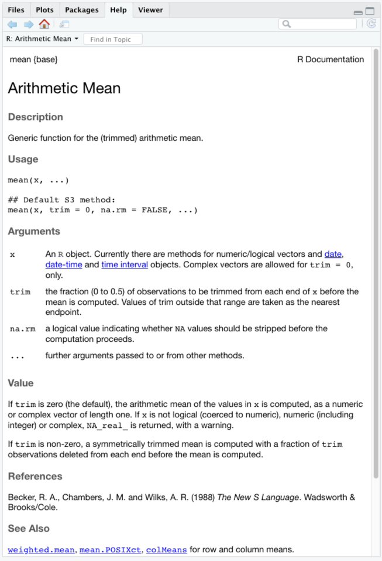

This file gives us all the information we need to use the `mean()` function. I will concentrate on the most important bits: there is a `Description` (what the function does), there is information on how the function should be used (`Usage`) which also gives details on the default setting of the function, there are a list of `Arguments` which the function can or needs to have, a `Value` section where there are some more details, a `References` section (where applicable), a `See Also` section which suggests other related functions which might be useful, and at the very bottom a section of `Examples` where you can see some basic examples of how the function can be used.

The key bits at the moment are the default usage and the arguments.

The “Usage” section tells us that we need to proved (at least) something called “x” to the function - `mean(x, ...)`. If we look at the Arguments section you can see that it describes x (*An R object. Currently there are methods for numeric/logical vectors and date, date-time and time interval objects. Complex vectors are allowed for trim = 0, only.*). So this says that we need to provide an r object (i.e. data) which can be numeric or logical or a few other things (date, time). So the minimum requirement to calculate the mean is a vector. This makes sense, and is the reason that `mean(x, ...)` only has the `x` present in the usage section. There is then a `...` after the x. This indicates that the function can take other arguments, but that you don’t have to specify them (i.e. there are some default settings that the function will use if you dont make any other specifications) you can see these default assumptions in the section:

```
## Default S3 method:
mean(x, trim = 0, na.rm = FALSE, ...)
```

So this is telling us how the function behaves when it is given only the minimum input (remember - `mean(x, ...)`). We can look at the “Arguments” section to find out more about what these other arguements do, and what the defaults mean.

The arguments section tells us that `trim` is `the fraction (0 to 0.5) of observations to be trimmed from each end of x before the mean is computed. Values of trim outside that range are taken as the nearest endpoint`. We can see if we look at the Default S3 Method section that the default setting is not to trim (`trim = 0`).

The second argument which is specified in the default section is `na.rm`: `a logical value indicating whether NA values should be stripped before the computation proceeds`. So, we have learned that `na.rm` needs a logical value (remember `TRUE` or `FALSE` or `T` or `F`), and that the default is `FALSE`. We met NA’s very briefly earlier on - remember NA’s are missing data. They can be included in either numeric or character vectors, and this argument `na.rm` in `mean()` gives us the option of `mean()` removing any NA’s from the vector before calculating the mean value of the vector. For example:

```r
##make a vector which includes an NA value:
vec <- c(1, 5, 6, 3, NA, 10, 12)

##try and calculate the mean value:
mean(vec)
```

```
## [1] NA
```

You can see that this has returned an NA value because R doenst know what you want to do with the NA value in the vector. Is it there by accident? or can R just continue and ignore it? If we tell R to ignore the NA’s (`na.rm = TRUE`) then:

```r
##try and calculate the mean value, ignoring any NA values:
mean(vec, na.rm = T)
```

```
## [1] 6.166667
```

We get the mean of the remaining values.

The studious amongst you will have noticed that the first argument in `mean()` is called `x` and - whilst we spelled out that `na.rm` was given the value TRUE (by doing `na.rm = T`), we never actually told `mean()` that the object `vec` was the data we wanted to use for argument x, i.e. we didnt ever type `x = vec` even when we wanted the function to use `vec` as `x`:

```r
mean(x = vec, na.rm = T)
```

The reason for this is that R by default assumes that if you put arguments into a function, they are going in in the *correct order* as listed in the help file for the function. Which means that:

```r
##a vector
vec <- c(1, 5, 6, 3, NA, 10, 12)

##this
mean(vec)

## is the same as
mean(x = vec)
```

This is both convenient (its quick) and dangerous (if you get the order of the arguments wrong). The best way to avoid this is to list all the arguments you are using in the function in full. If you do this then there is no issue about getting the arguments in the “correct” order - as R will find them. So for the `mean()` function we used above all the following are equivelant (even though the orders are different):

```r
##this
mean(x = vec, na.rm = T)

##is the same as this
mean(na.rm = T, x = vec)

##is the same as this
mean(x = vec, trim = 0, na.rm = T)

##is the same as this
mean(x = vec, na.rm = T, trim = 0)
```

etc…

In the above example the first one `mean(x = vec, na.rm = T)` is the best code as the “trim” argument isnt neccesary (we are using the default value of 0) and the order is correct

The R help files which are displayed when you use the `?` are a critical part of you being able to use R as you need to know what data and arguments your functions need to be able to run as you expect.

### 6.3.2 Help from Google

The `?` approach detailed above is great to find out what a specific function does, but if you are struggling to get a function working, or find a function to do what you need, then google is the best place to look. A huge number of people use R, and almost certainly all of the problems you will encounter have been encountered before, and someone has asked a question about them. https://stackoverflow.com/ is an excellent resource for R help and is easy to navigate. Blogs like [R-bloggers](https://www.r-bloggers.com/) also have lots of useful tutorials and help pages.

In reality most of us who code spend a lot of time googling for answers to problems, and using/adapting bits of other peoples code to achieve the things we need to. Being a good code-googler is perhaphs one of the most important skills you can develop during this course.

## 6.4 Nesting functions

One of the key concepts in this course is producing efficient and easy to read code which is fast to handle big data. This can be helped by nesting functions inside one another, for example using some of the functinons we encountered earlier:

```r
##generate 10 random numbers between 0 and 20, take the squareroot of those numbers, and then calculate the mean
mean(x = sqrt(x = runif(n=10, min=0, max=20)))
```

```
## [1] 3.614218
```

You can see that here we have 3 functions nested within on another, and R evaluates each one in turn from the **inner most** function to the outermost - i.e. starting with `runif()`, carrying out that command, and then running `sqrt()`, and then calculating the `mean()`.

This can make your code much more effecient (both in speed and in the amount of space it takes to write), but the more functions you nest inside one another the harder it is for us humans to read. So keeping good annotations (as above) is critical to keeping the code understandable.

## 6.6 Beyond `base` R

Whilst `base` R includes a lot of very useful functions, it isnt exhaustive and we may (will) want to use functions which are not included in the basic installation. These are contained in “packages” which can be downloaded and installed so we can use those functions in our R scripts. We will cover this during the next workshop.

## 6.7 Writing your own functions

Sometimes there isnt going to be a function that does exactly what you want, but R allows you to define new functions very easily and then use them in your script. We will go through the process very quickly, and will return to it again in the following workshops.

Writing a function requires slighty different syntax to using a function. Lets explore this. First, we decide what we want to call our function. In the example below we are going to calculate the standard error of a numeric vector, so we will call it `se`. You can see that we are making an object called `se` using the assignment operator `<-`, and we are telling R that this object `se` is going to be a function.

```r
##this is the how you specify that se is going to be a function
se <- function()
```

However, the above isn’t a function - we need to tell R what arguments our function will take (remember, arguments are the bits that go in the parentheses: `mean(x)` - x is the argument), and what our function will do if you provide it those arguments. To do this we have to add some additional detail to the above. We tell R what arguments our function is going to take by adding their names into the parentheses of `function()`:

```r
##here we are creating a function called se and telling R it needs an object called x
se <- function(x)
```

This still isnt a working function (as we haven’t told R what the function is going to do with x yet) but R now knows then when it runs your function it needs to look for an object called x - just like in `mean(x)`.

When you are writing your function you can define the names of the arguments your function needs, and there are likely to be more than one, e.g.:

```r
##an example function with three arguments
a_new_function <- function(data, na.rm, round)
```

But we are going to stick to calculating standard error here, and just using 1 argument - the data we want to calculate the standard error for.

So we have specified the argument the function needs (x) but we havent specified what we want the function to do with x. We do this by using curly brackets `{}`:

```r
##this is the how you specify what the function does
##everything in the curly brackets will be carried out when you run the function
se <- function(x){

}
```

The curly bracets after the `()` tells R that this function, with these arguments, will carry out this piece of code.

*Note* - you can (and probably will) want to pass multiple arguments to a function - these can be multiple data sets, or arguments such as remove NAs, or make a certain assumption. These are all specificed in the `()` of the function:

```r
##you specify multiple arguments like this:
se <- function(x, y, z, etc){

}
```

To calcualte standard error (which is the standard deviation of the data divided by the square root of the number of data points) we can specify the following:

```r
##this is the how you specify what the function does
##everything in the curly brackets will be carried out when you run the function
se <- function(x){
  ##we will use the existing functions `sd()` which calculates standard deviation
  ##`sqrt()` which calculates the squareroot of numeric values
  ## and `length()` which we know from earlier gives us the length of the vector (i.e. number of data points)
  std_er<-sd(x)/sqrt(length(x))
  ## the `return()` - see below
  return(std_er)
}
```

So we use some existing functions to make a new object - called std_er - which will be the standard error of a vector we provide to this function.

The next line of code - the `return(std_er)` - tells R this this is the result we want the function to return (give us back) after the calculations have been done. We briefly mentioned the Global Environment earlier on - and that R can find objects in the Global Environment (see the top right pannel of RStudio). The reason we have to specify `return(std_er)` is that when you run a function R creates a new (temporary) environment which the function operates in. The calculations are carried out in this local (not global environment) and then the memory used by that function is cleared and made available again after the function has finished. So, we need to specify to R that in our function `se` we want the `std_er` object to be returned to the global R environment, so we can use it with other functions.

Try inserting the above code into your R console and running it. You should see that the code runs fine, but that nothing seems to happen. In fact R has created a new function - you can see it if you look in your global environment pannel (you might need to scroll down). It shows that the function is called `se` and it takes the argument `x`. If you want to see what code inside the function is, you can simply run the function’s name:

```r
##look at the function code:
se
```

```
## function(x){
##   ##we will use the existing functions `sd()` which calculates standard deviation
##   ##`sqrt()` which calculates the squareroot of numeric values
##   ## and `length()` which we know from earlier gives us the length of the vector (i.e. number of data points)
##   std_er<-sd(x)/sqrt(length(x))
##   ## the `return()` - see below
##   return(std_er)
## }
```

Because this function is now in the global environment, we can use it like any other R function. Try to funish the below code:

```r
## make a vector of random numbers using the runif() function
## save this as a vector
runif()

##then apply the se() function to this vector:
se(x = )
```

You should see that the `se()` function returns a single value which is the standard error of your vector. Fantastic!

As you can imagine writing functions gets much more complex, but these are the basic tools you need to write your own complex functions later on in the course.

# 7 Key Concepts

- Working in the console vs writing a script
- Annotating your code
- Assigning objects
- Inf, Nan, NA
- Naming conventions
- Vectors (numeric, character, logical)
- Accessing data using `[]`
- Logical operators (==, !=, >, etc)
- Functions
- Writing your own functions
- Getting help

# 8 Functions covered today

| Function | Call |
| --- | --- |
| Create a vector | `c()` |
| Return the length of a vector | `length()` |
| Check the names of a vector or add names to a vector | `names()` |
| Sort a vector by value | `sort()` |
| Make a vector into a factor | `as.factor()` |
| Generate random numbers from a uniform distribution | `runif()` |
| Add up the values of a vector | `sum()` |
| Calculate the average of the values of a vector | `mean()` |
| Round a vector to the nearest …. | `round()` |
| Square root of the values in a vector | `sqrt()` |
| Create a function | `function()` |
| Return the desired object from a function | `return()` |

# 9 Cheat sheets

[`base` R cheatsheet](https://iqss.github.io/dss-workshops/R/Rintro/base-r-cheat-sheet.pdf).

# 10 Homework

Each week we will set some further coding tasks for you to do, and we will be giving you (formative - i.e. not marked) feedback on these tasks on a weekly basis. This weeks homework:

1. The first thing to do is to ensure you have gone through - and understood - the information above in full. This forms the building blocks of the rest of the course and is critical for you to understand.
2. To help reinforce this below is some work to carry out before next week. We haven’t covered all of the functions, but you have all the tools to be able to do the following:
- Some easy code
  - Create a vector of 100 random numbers between 0 and 50
  - Sort these by order of their value (from largest to smallest)
  - Write a function which calculates the logarithm (base 10) of a vector it is given, subtracts this from the original vector, and returns the new vector of values
  - Use this function with your vector of random numbers and save the output as a new object
  - calculate the mean, standard deviation, and standard error of this new object, save these into a single vector where each of the objects are named
- Some more advanced coding:
  - Write code to create a sequence of numbers from 15 to 100, find the mean of the numbers in this vector which are greater than 20 and less than 60, and the sum of the numbers in this vector which are greater than 48.
  - Write a function which returns the maximum and minimum values of a vector, *without* using the `max()`, `min()`, or `range()` functions

Remember when you are doing this homework to apply the best practices we talked about earlier (e.g. annotating code) to your work, and set it out in a clear, logical way. Once you have done this, please upload your work to the blackboard site for this course.